# 03-dplyr

Author

Milo Coolman

## 3.1.1

```r
library(babynames)
library(tidyverse)
babynames |> filter(name == "Matthew")
```

```
# A tibble: 212 × 5
    year sex   name        n     prop
   <dbl> <chr> <chr>   <int>    <dbl>
 1  1880 M     Matthew   113 0.000954
 2  1881 M     Matthew    80 0.000739
 3  1882 M     Matthew   109 0.000893
 4  1883 M     Matthew    86 0.000765
 5  1884 M     Matthew   117 0.000953
 6  1885 M     Matthew   111 0.000957
 7  1886 M     Matthew   112 0.000941
 8  1887 M     Matthew   108 0.000988
 9  1888 M     Matthew   114 0.000878
10  1889 M     Matthew   118 0.000991
# ℹ 202 more rows
```

```r
babynames |> filter(year >= 2000)
```

```
# A tibble: 591,925 × 5
    year sex   name          n    prop
   <dbl> <chr> <chr>     <int>   <dbl>
 1  2000 F     Emily     25953 0.0130
 2  2000 F     Hannah    23080 0.0116
 3  2000 F     Madison   19967 0.0100
 4  2000 F     Ashley    17997 0.00902
 5  2000 F     Sarah     17697 0.00887
 6  2000 F     Alexis    17629 0.00884
 7  2000 F     Samantha  17266 0.00866
 8  2000 F     Jessica   15709 0.00787
 9  2000 F     Elizabeth 15094 0.00757
10  2000 F     Taylor    15078 0.00756
# ℹ 591,915 more rows
```

```r
babynames |> filter(sex != "M")
```

```
# A tibble: 1,138,293 × 5
    year sex   name          n   prop
   <dbl> <chr> <chr>     <int>  <dbl>
 1  1880 F     Mary       7065 0.0724
 2  1880 F     Anna       2604 0.0267
 3  1880 F     Emma       2003 0.0205
 4  1880 F     Elizabeth  1939 0.0199
 5  1880 F     Minnie     1746 0.0179
 6  1880 F     Margaret   1578 0.0162
 7  1880 F     Ida        1472 0.0151
 8  1880 F     Alice      1414 0.0145
 9  1880 F     Bertha     1320 0.0135
10  1880 F     Sarah      1288 0.0132
# ℹ 1,138,283 more rows
```

```r
babynames |> filter(prop > 0.05)
```

```
# A tibble: 168 × 5
    year sex   name        n   prop
   <dbl> <chr> <chr>   <int>  <dbl>
 1  1880 F     Mary     7065 0.0724
 2  1880 M     John     9655 0.0815
 3  1880 M     William  9532 0.0805
 4  1880 M     James    5927 0.0501
 5  1881 F     Mary     6919 0.0700
 6  1881 M     John     8769 0.0810
 7  1881 M     William  8524 0.0787
 8  1881 M     James    5441 0.0502
 9  1882 F     Mary     8148 0.0704
10  1882 M     John     9557 0.0783
# ℹ 158 more rows
```

```r
babynames |> filter(year == max(year))
```

```
# A tibble: 32,469 × 5
    year sex   name          n    prop
   <dbl> <chr> <chr>     <int>   <dbl>
 1  2017 F     Emma      19738 0.0105
 2  2017 F     Olivia    18632 0.00994
 3  2017 F     Ava       15902 0.00848
 4  2017 F     Isabella  15100 0.00805
 5  2017 F     Sophia    14831 0.00791
 6  2017 F     Mia       13437 0.00717
 7  2017 F     Charlotte 12893 0.00688
 8  2017 F     Amelia    11800 0.00629
 9  2017 F     Evelyn    10675 0.00569
10  2017 F     Abigail   10551 0.00563
# ℹ 32,459 more rows
```

```r
babynames |> filter(n > 20000 | prop > 0.05)
```

```
# A tibble: 2,301 × 5
    year sex   name        n   prop
   <dbl> <chr> <chr>   <int>  <dbl>
 1  1880 F     Mary     7065 0.0724
 2  1880 M     John     9655 0.0815
 3  1880 M     William  9532 0.0805
 4  1880 M     James    5927 0.0501
 5  1881 F     Mary     6919 0.0700
 6  1881 M     John     8769 0.0810
 7  1881 M     William  8524 0.0787
 8  1881 M     James    5441 0.0502
 9  1882 F     Mary     8148 0.0704
10  1882 M     John     9557 0.0783
# ℹ 2,291 more rows
```

```r
babynames |> filter(sex == "F" & name == "Mary")
```

```
# A tibble: 138 × 5
    year sex   name      n   prop
   <dbl> <chr> <chr> <int>  <dbl>
 1  1880 F     Mary   7065 0.0724
 2  1881 F     Mary   6919 0.0700
 3  1882 F     Mary   8148 0.0704
 4  1883 F     Mary   8012 0.0667
 5  1884 F     Mary   9217 0.0670
 6  1885 F     Mary   9128 0.0643
 7  1886 F     Mary   9889 0.0643
 8  1887 F     Mary   9888 0.0636
 9  1888 F     Mary  11754 0.0620
10  1889 F     Mary  11648 0.0616
# ℹ 128 more rows
```

```r
babynames |> filter(sex == "F" & name == "Mary" & prop > 0.05)
```

```
# A tibble: 58 × 5
    year sex   name      n   prop
   <dbl> <chr> <chr> <int>  <dbl>
 1  1880 F     Mary   7065 0.0724
 2  1881 F     Mary   6919 0.0700
 3  1882 F     Mary   8148 0.0704
 4  1883 F     Mary   8012 0.0667
 5  1884 F     Mary   9217 0.0670
 6  1885 F     Mary   9128 0.0643
 7  1886 F     Mary   9889 0.0643
 8  1887 F     Mary   9888 0.0636
 9  1888 F     Mary  11754 0.0620
10  1889 F     Mary  11648 0.0616
# ℹ 48 more rows
```

```r
babynames |> slice(1:5)
```

```
# A tibble: 5 × 5
   year sex   name          n   prop
  <dbl> <chr> <chr>     <int>  <dbl>
1  1880 F     Mary       7065 0.0724
2  1880 F     Anna       2604 0.0267
3  1880 F     Emma       2003 0.0205
4  1880 F     Elizabeth  1939 0.0199
5  1880 F     Minnie     1746 0.0179
```

# Exercise 1 - 4

```r
babynames |> filter(name == "Milo")
```

```
# A tibble: 157 × 5
    year sex   name      n     prop
   <dbl> <chr> <chr> <int>    <dbl>
 1  1880 M     Milo     26 0.000220
 2  1881 M     Milo     19 0.000175
 3  1882 M     Milo     27 0.000221
 4  1883 M     Milo     20 0.000178
 5  1884 M     Milo     22 0.000179
 6  1885 M     Milo     21 0.000181
 7  1886 M     Milo     24 0.000202
 8  1887 M     Milo     23 0.000210
 9  1888 M     Milo     20 0.000154
10  1889 M     Milo     17 0.000143
# ℹ 147 more rows
```

```r
babynames |> filter(year >= 2000)
```

```
# A tibble: 591,925 × 5
    year sex   name          n    prop
   <dbl> <chr> <chr>     <int>   <dbl>
 1  2000 F     Emily     25953 0.0130
 2  2000 F     Hannah    23080 0.0116
 3  2000 F     Madison   19967 0.0100
 4  2000 F     Ashley    17997 0.00902
 5  2000 F     Sarah     17697 0.00887
 6  2000 F     Alexis    17629 0.00884
 7  2000 F     Samantha  17266 0.00866
 8  2000 F     Jessica   15709 0.00787
 9  2000 F     Elizabeth 15094 0.00757
10  2000 F     Taylor    15078 0.00756
# ℹ 591,915 more rows
```

```r
babynames |> filter(name == "Milo" & year >= 2000)
```

```
# A tibble: 29 × 5
    year sex   name      n       prop
   <dbl> <chr> <chr> <int>      <dbl>
 1  2000 M     Milo    127 0.0000608
 2  2001 M     Milo    156 0.0000755
 3  2002 M     Milo    210 0.000102
 4  2003 M     Milo    220 0.000105
 5  2004 M     Milo    236 0.000112
 6  2005 M     Milo    282 0.000133
 7  2006 F     Milo      6 0.00000287
 8  2006 M     Milo    336 0.000153
 9  2007 M     Milo    475 0.000215
10  2008 F     Milo     11 0.00000529
# ℹ 19 more rows
```

```r
babynames |> slice(1:20)
```

```
# A tibble: 20 × 5
    year sex   name          n    prop
   <dbl> <chr> <chr>     <int>   <dbl>
 1  1880 F     Mary       7065 0.0724
 2  1880 F     Anna       2604 0.0267
 3  1880 F     Emma       2003 0.0205
 4  1880 F     Elizabeth  1939 0.0199
 5  1880 F     Minnie     1746 0.0179
 6  1880 F     Margaret   1578 0.0162
 7  1880 F     Ida        1472 0.0151
 8  1880 F     Alice      1414 0.0145
 9  1880 F     Bertha     1320 0.0135
10  1880 F     Sarah      1288 0.0132
11  1880 F     Annie      1258 0.0129
12  1880 F     Clara      1226 0.0126
13  1880 F     Ella       1156 0.0118
14  1880 F     Florence   1063 0.0109
15  1880 F     Cora       1045 0.0107
16  1880 F     Martha     1040 0.0107
17  1880 F     Laura      1012 0.0104
18  1880 F     Nellie      995 0.0102
19  1880 F     Grace       982 0.0101
20  1880 F     Carrie      949 0.00972
```

# 3.1.2

```r
babynames |> arrange(n)
```

```
# A tibble: 1,924,665 × 5
    year sex   name          n      prop
   <dbl> <chr> <chr>     <int>     <dbl>
 1  1880 F     Adelle        5 0.0000512
 2  1880 F     Adina         5 0.0000512
 3  1880 F     Adrienne      5 0.0000512
 4  1880 F     Albertine     5 0.0000512
 5  1880 F     Alys          5 0.0000512
 6  1880 F     Ana           5 0.0000512
 7  1880 F     Araminta      5 0.0000512
 8  1880 F     Arthur        5 0.0000512
 9  1880 F     Birtha        5 0.0000512
10  1880 F     Bulah         5 0.0000512
# ℹ 1,924,655 more rows
```

```r
babynames |> arrange(desc(n))
```

```
# A tibble: 1,924,665 × 5
    year sex   name        n   prop
   <dbl> <chr> <chr>   <int>  <dbl>
 1  1947 F     Linda   99686 0.0548
 2  1948 F     Linda   96209 0.0552
 3  1947 M     James   94756 0.0510
 4  1957 M     Michael 92695 0.0424
 5  1947 M     Robert  91642 0.0493
 6  1949 F     Linda   91016 0.0518
 7  1956 M     Michael 90620 0.0423
 8  1958 M     Michael 90520 0.0420
 9  1948 M     James   88588 0.0497
10  1954 M     Michael 88514 0.0428
# ℹ 1,924,655 more rows
```

# Exercises 5 - 6

6. It seems to organize the names into alphabetical order with a secondary method of organization being year

```r
babynames |> arrange(desc(prop))
```

```
# A tibble: 1,924,665 × 5
    year sex   name        n   prop
   <dbl> <chr> <chr>   <int>  <dbl>
 1  1880 M     John     9655 0.0815
 2  1881 M     John     8769 0.0810
 3  1880 M     William  9532 0.0805
 4  1883 M     John     8894 0.0791
 5  1881 M     William  8524 0.0787
 6  1882 M     John     9557 0.0783
 7  1884 M     John     9388 0.0765
 8  1882 M     William  9298 0.0762
 9  1886 M     John     9026 0.0758
10  1885 M     John     8756 0.0755
# ℹ 1,924,655 more rows
```

```r
babynames |> arrange(name)
```

```
# A tibble: 1,924,665 × 5
    year sex   name      n       prop
   <dbl> <chr> <chr> <int>      <dbl>
 1  2007 M     Aaban     5 0.00000226
 2  2009 M     Aaban     6 0.00000283
 3  2010 M     Aaban     9 0.00000439
 4  2011 M     Aaban    11 0.00000542
 5  2012 M     Aaban    11 0.00000543
 6  2013 M     Aaban    14 0.00000694
 7  2014 M     Aaban    16 0.00000783
 8  2015 M     Aaban    15 0.00000736
 9  2016 M     Aaban     9 0.00000446
10  2017 M     Aaban    11 0.0000056
# ℹ 1,924,655 more rows
```

# 3.1.3

```r
babynames |> select(name, n)
```

```
# A tibble: 1,924,665 × 2
   name          n
   <chr>     <int>
 1 Mary       7065
 2 Anna       2604
 3 Emma       2003
 4 Elizabeth  1939
 5 Minnie     1746
 6 Margaret   1578
 7 Ida        1472
 8 Alice      1414
 9 Bertha     1320
10 Sarah      1288
# ℹ 1,924,655 more rows
```

```r
babynames |> select(-sex, -prop)
```

```
# A tibble: 1,924,665 × 3
    year name          n
   <dbl> <chr>     <int>
 1  1880 Mary       7065
 2  1880 Anna       2604
 3  1880 Emma       2003
 4  1880 Elizabeth  1939
 5  1880 Minnie     1746
 6  1880 Margaret   1578
 7  1880 Ida        1472
 8  1880 Alice      1414
 9  1880 Bertha     1320
10  1880 Sarah      1288
# ℹ 1,924,655 more rows
```

```r
babynames |> select(name,, everything())
```

```
# A tibble: 1,924,665 × 5
   name       year sex       n   prop
   <chr>     <dbl> <chr> <int>  <dbl>
 1 Mary       1880 F      7065 0.0724
 2 Anna       1880 F      2604 0.0267
 3 Emma       1880 F      2003 0.0205
 4 Elizabeth  1880 F      1939 0.0199
 5 Minnie     1880 F      1746 0.0179
 6 Margaret   1880 F      1578 0.0162
 7 Ida        1880 F      1472 0.0151
 8 Alice      1880 F      1414 0.0145
 9 Bertha     1880 F      1320 0.0135
10 Sarah      1880 F      1288 0.0132
# ℹ 1,924,655 more rows
```

# Exercise 7

```r
babynames |> select(year, name, prop)
```

```
# A tibble: 1,924,665 × 3
    year name        prop
   <dbl> <chr>      <dbl>
 1  1880 Mary      0.0724
 2  1880 Anna      0.0267
 3  1880 Emma      0.0205
 4  1880 Elizabeth 0.0199
 5  1880 Minnie    0.0179
 6  1880 Margaret  0.0162
 7  1880 Ida       0.0151
 8  1880 Alice     0.0145
 9  1880 Bertha    0.0135
10  1880 Sarah     0.0132
# ℹ 1,924,655 more rows
```

```r
babynames |> select(-sex, -n)
```

```
# A tibble: 1,924,665 × 3
    year name        prop
   <dbl> <chr>      <dbl>
 1  1880 Mary      0.0724
 2  1880 Anna      0.0267
 3  1880 Emma      0.0205
 4  1880 Elizabeth 0.0199
 5  1880 Minnie    0.0179
 6  1880 Margaret  0.0162
 7  1880 Ida       0.0151
 8  1880 Alice     0.0145
 9  1880 Bertha    0.0135
10  1880 Sarah     0.0132
# ℹ 1,924,655 more rows
```

# 3.1.4

```r
babynames |> filter(name == "Matthew")
```

```
# A tibble: 212 × 5
    year sex   name        n     prop
   <dbl> <chr> <chr>   <int>    <dbl>
 1  1880 M     Matthew   113 0.000954
 2  1881 M     Matthew    80 0.000739
 3  1882 M     Matthew   109 0.000893
 4  1883 M     Matthew    86 0.000765
 5  1884 M     Matthew   117 0.000953
 6  1885 M     Matthew   111 0.000957
 7  1886 M     Matthew   112 0.000941
 8  1887 M     Matthew   108 0.000988
 9  1888 M     Matthew   114 0.000878
10  1889 M     Matthew   118 0.000991
# ℹ 202 more rows
```

```r
babynames_matthew <- babynames |> filter(name == "Matthew")
```

# Exercise 8

```r
babynames_milo <- babynames |> filter(name == "Milo")
babynames_milo
```

```
# A tibble: 157 × 5
    year sex   name      n     prop
   <dbl> <chr> <chr> <int>    <dbl>
 1  1880 M     Milo     26 0.000220
 2  1881 M     Milo     19 0.000175
 3  1882 M     Milo     27 0.000221
 4  1883 M     Milo     20 0.000178
 5  1884 M     Milo     22 0.000179
 6  1885 M     Milo     21 0.000181
 7  1886 M     Milo     24 0.000202
 8  1887 M     Milo     23 0.000210
 9  1888 M     Milo     20 0.000154
10  1889 M     Milo     17 0.000143
# ℹ 147 more rows
```

# 3.1.5

```r
fitness_df <- read_csv("https://raw.githubusercontent.com/highamm/ds234_quarto/main/data_online/higham_fitness_clean.csv",
                       col_types = list(stepgoal = col_factor()))
fitness_df
```

```
# A tibble: 1,722 × 9
   Start      active_cals distance flights  steps month weekday dayofyear
   <date>           <dbl>    <dbl>   <dbl>  <dbl> <chr> <chr>       <dbl>
 1 2018-11-28        57.8    0.930       0  1885. Nov   Wed           332
 2 2018-11-29       509.     4.64       18  8953. Nov   Thu           333
 3 2018-11-30       599.     6.05       12 11665  Nov   Fri           334
 4 2018-12-01       661.     6.80        6 12117  Dec   Sat           335
 5 2018-12-02       527.     4.61        1  8925. Dec   Sun           336
 6 2018-12-03       550.     3.96        2  7205  Dec   Mon           337
 7 2018-12-04       670.     6.60        5 12483. Dec   Tue           338
 8 2018-12-05       557.     4.91        6  9258. Dec   Wed           339
 9 2018-12-06       997.     7.50       13 14208  Dec   Thu           340
10 2018-12-07       533.     4.27        8  8269. Dec   Fri           341
# ℹ 1,712 more rows
# ℹ 1 more variable: stepgoal <fct>
```

```r
fitness_df |> filter(weekday == "Sat" | weekday == "Sun") |>
  arrange(desc(steps))
```

```
# A tibble: 492 × 9
   Start      active_cals distance flights  steps month weekday dayofyear
   <date>           <dbl>    <dbl>   <dbl>  <dbl> <chr> <chr>       <dbl>
 1 2023-07-15       2291.    18.0      193 32589. Jul   Sat           196
 2 2019-08-11       1385.    15.8      173 29480. Aug   Sun           223
 3 2019-04-14       1767.    17.9        1 25578  Apr   Sun           104
 4 2018-12-15       1091.    11.2       27 21224. Dec   Sat           349
 5 2022-05-29       1291.    11.8      103 20853  May   Sun           149
 6 2019-02-10       1392.    12.8        5 20700. Feb   Sun            41
 7 2020-08-15          0      9.06      90 19065  Aug   Sat           228
 8 2021-09-04       1622.    10.1      132 18470  Sep   Sat           247
 9 2021-05-23       1162.     9.41      41 16625  May   Sun           143
10 2019-07-07        871.     9.95       4 16484. Jul   Sun           188
# ℹ 482 more rows
# ℹ 1 more variable: stepgoal <fct>
```

```r
fitness_df |> filter(weekday == "Sat" | weekday == "Sun")
```

```
# A tibble: 492 × 9
   Start      active_cals distance flights  steps month weekday dayofyear
   <date>           <dbl>    <dbl>   <dbl>  <dbl> <chr> <chr>       <dbl>
 1 2018-12-01        661.     6.80       6 12117  Dec   Sat           335
 2 2018-12-02        527.     4.61       1  8925. Dec   Sun           336
 3 2018-12-08        775.     6.46       0  8834. Dec   Sat           342
 4 2018-12-09        341.     2.81       0  5265  Dec   Sun           343
 5 2018-12-15       1091.    11.2       27 21224. Dec   Sat           349
 6 2018-12-16       1029.     8.84      79 16376  Dec   Sun           350
 7 2018-12-22        435.     2.23       8  4204. Dec   Sat           356
 8 2018-12-23        353.     2.40       8  4286  Dec   Sun           357
 9 2018-12-29        538.     3.49       6  6570. Dec   Sat           363
10 2018-12-30        317.     1.21       4  2285. Dec   Sun           364
# ℹ 482 more rows
# ℹ 1 more variable: stepgoal <fct>
```

```r
filter(fitness_df, weekday == "Sat" | weekday == "Sun")
```

```
# A tibble: 492 × 9
   Start      active_cals distance flights  steps month weekday dayofyear
   <date>           <dbl>    <dbl>   <dbl>  <dbl> <chr> <chr>       <dbl>
 1 2018-12-01        661.     6.80       6 12117  Dec   Sat           335
 2 2018-12-02        527.     4.61       1  8925. Dec   Sun           336
 3 2018-12-08        775.     6.46       0  8834. Dec   Sat           342
 4 2018-12-09        341.     2.81       0  5265  Dec   Sun           343
 5 2018-12-15       1091.    11.2       27 21224. Dec   Sat           349
 6 2018-12-16       1029.     8.84      79 16376  Dec   Sun           350
 7 2018-12-22        435.     2.23       8  4204. Dec   Sat           356
 8 2018-12-23        353.     2.40       8  4286  Dec   Sun           357
 9 2018-12-29        538.     3.49       6  6570. Dec   Sat           363
10 2018-12-30        317.     1.21       4  2285. Dec   Sun           364
# ℹ 482 more rows
# ℹ 1 more variable: stepgoal <fct>
```

```r
filter(fitness_df, weekday == "Sat" | weekday == "Sun") |> arrange(desc(steps))
```

```
# A tibble: 492 × 9
   Start      active_cals distance flights  steps month weekday dayofyear
   <date>           <dbl>    <dbl>   <dbl>  <dbl> <chr> <chr>       <dbl>
 1 2023-07-15       2291.    18.0      193 32589. Jul   Sat           196
 2 2019-08-11       1385.    15.8      173 29480. Aug   Sun           223
 3 2019-04-14       1767.    17.9        1 25578  Apr   Sun           104
 4 2018-12-15       1091.    11.2       27 21224. Dec   Sat           349
 5 2022-05-29       1291.    11.8      103 20853  May   Sun           149
 6 2019-02-10       1392.    12.8        5 20700. Feb   Sun            41
 7 2020-08-15          0      9.06      90 19065  Aug   Sat           228
 8 2021-09-04       1622.    10.1      132 18470  Sep   Sat           247
 9 2021-05-23       1162.     9.41      41 16625  May   Sun           143
10 2019-07-07        871.     9.95       4 16484. Jul   Sun           188
# ℹ 482 more rows
# ℹ 1 more variable: stepgoal <fct>
```

```r
arrange(filter(fitness_df, weekday == "Sat" | weekday == "Sun"), desc(steps))
```

```
# A tibble: 492 × 9
   Start      active_cals distance flights  steps month weekday dayofyear
   <date>           <dbl>    <dbl>   <dbl>  <dbl> <chr> <chr>       <dbl>
 1 2023-07-15       2291.    18.0      193 32589. Jul   Sat           196
 2 2019-08-11       1385.    15.8      173 29480. Aug   Sun           223
 3 2019-04-14       1767.    17.9        1 25578  Apr   Sun           104
 4 2018-12-15       1091.    11.2       27 21224. Dec   Sat           349
 5 2022-05-29       1291.    11.8      103 20853  May   Sun           149
 6 2019-02-10       1392.    12.8        5 20700. Feb   Sun            41
 7 2020-08-15          0      9.06      90 19065  Aug   Sat           228
 8 2021-09-04       1622.    10.1      132 18470  Sep   Sat           247
 9 2021-05-23       1162.     9.41      41 16625  May   Sun           143
10 2019-07-07        871.     9.95       4 16484. Jul   Sun           188
# ℹ 482 more rows
# ℹ 1 more variable: stepgoal <fct>
```

# Exercise 9

```r
fitness_df |> filter(active_cals > 50)
```

```
# A tibble: 1,690 × 9
   Start      active_cals distance flights  steps month weekday dayofyear
   <date>           <dbl>    <dbl>   <dbl>  <dbl> <chr> <chr>       <dbl>
 1 2018-11-28        57.8    0.930       0  1885. Nov   Wed           332
 2 2018-11-29       509.     4.64       18  8953. Nov   Thu           333
 3 2018-11-30       599.     6.05       12 11665  Nov   Fri           334
 4 2018-12-01       661.     6.80        6 12117  Dec   Sat           335
 5 2018-12-02       527.     4.61        1  8925. Dec   Sun           336
 6 2018-12-03       550.     3.96        2  7205  Dec   Mon           337
 7 2018-12-04       670.     6.60        5 12483. Dec   Tue           338
 8 2018-12-05       557.     4.91        6  9258. Dec   Wed           339
 9 2018-12-06       997.     7.50       13 14208  Dec   Thu           340
10 2018-12-07       533.     4.27        8  8269. Dec   Fri           341
# ℹ 1,680 more rows
# ℹ 1 more variable: stepgoal <fct>
```

## 3.2

# Class Exercises 1-4

```r
babynames |> filter(year == 2017, sex == "M") |> arrange(desc(n)) |> slice(1:10)
```

```
# A tibble: 10 × 5
    year sex   name         n    prop
   <dbl> <chr> <chr>    <int>   <dbl>
 1  2017 M     Liam     18728 0.00954
 2  2017 M     Noah     18326 0.00933
 3  2017 M     William  14904 0.00759
 4  2017 M     James    14232 0.00725
 5  2017 M     Logan    13974 0.00712
 6  2017 M     Benjamin 13733 0.00699
 7  2017 M     Mason    13502 0.00688
 8  2017 M     Elijah   13268 0.00676
 9  2017 M     Oliver   13141 0.00669
10  2017 M     Jacob    13106 0.00668
```

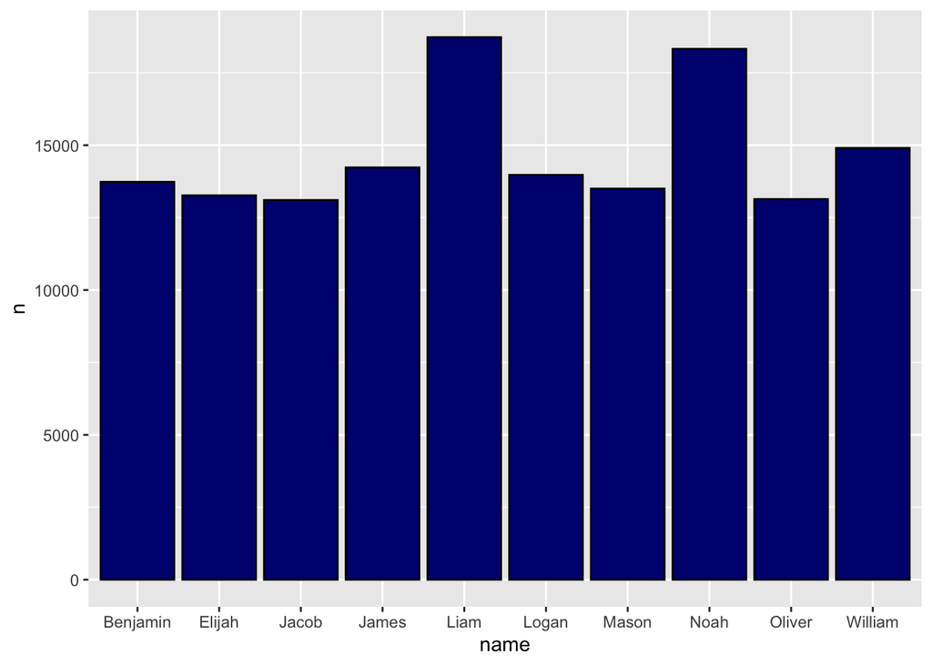

```r
top_10_male_2017 <- babynames |> filter(year == 2017, sex == "M") |> arrange(desc(n)) |> slice(1:10)
ggplot(data = top_10_male_2017, aes(x = name, y = n)) +
  geom_col(colour = "black", fill = "navyblue")
```

```r
babynames |> filter(name == "Milo" & sex == "M")
```

```
# A tibble: 138 × 5
    year sex   name      n     prop
   <dbl> <chr> <chr> <int>    <dbl>
 1  1880 M     Milo     26 0.000220
 2  1881 M     Milo     19 0.000175
 3  1882 M     Milo     27 0.000221
 4  1883 M     Milo     20 0.000178
 5  1884 M     Milo     22 0.000179
 6  1885 M     Milo     21 0.000181
 7  1886 M     Milo     24 0.000202
 8  1887 M     Milo     23 0.000210
 9  1888 M     Milo     20 0.000154
10  1889 M     Milo     17 0.000143
# ℹ 128 more rows
```

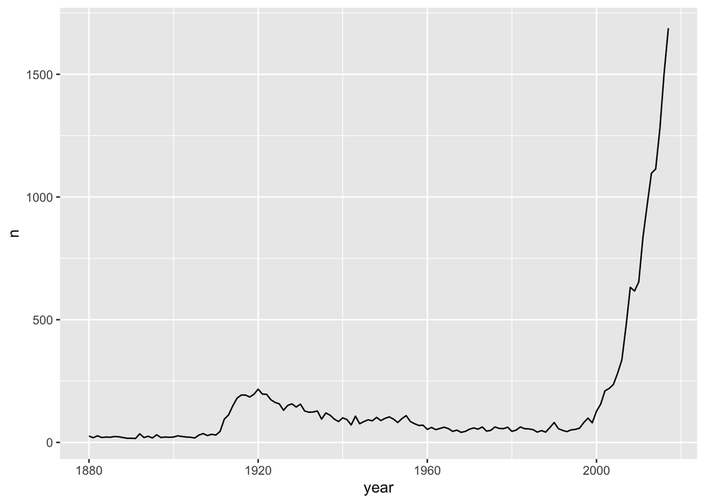

```r
milo_and_women <- babynames |> filter(name == "Milo" & sex == "M")
ggplot(data = milo_and_women, aes(x = year, y = n)) +
  geom_line()
```

# Class Exercise 5

When piping with data frames, the first argument of the function that we use must be for a data frame (not a vector like it is for ‘mean()’, and not a formula like it is for ‘lm()’)

# Your Turn 1-2

```r
babynames |> filter(year != 1945)
```

```
# A tibble: 1,915,641 × 5
    year sex   name          n   prop
   <dbl> <chr> <chr>     <int>  <dbl>
 1  1880 F     Mary       7065 0.0724
 2  1880 F     Anna       2604 0.0267
 3  1880 F     Emma       2003 0.0205
 4  1880 F     Elizabeth  1939 0.0199
 5  1880 F     Minnie     1746 0.0179
 6  1880 F     Margaret   1578 0.0162
 7  1880 F     Ida        1472 0.0151
 8  1880 F     Alice      1414 0.0145
 9  1880 F     Bertha     1320 0.0135
10  1880 F     Sarah      1288 0.0132
# ℹ 1,915,631 more rows
```

```r
babynames |> filter(n >= 400 & n <= 5000)
```

```
# A tibble: 84,451 × 5
    year sex   name          n   prop
   <dbl> <chr> <chr>     <int>  <dbl>
 1  1880 F     Anna       2604 0.0267
 2  1880 F     Emma       2003 0.0205
 3  1880 F     Elizabeth  1939 0.0199
 4  1880 F     Minnie     1746 0.0179
 5  1880 F     Margaret   1578 0.0162
 6  1880 F     Ida        1472 0.0151
 7  1880 F     Alice      1414 0.0145
 8  1880 F     Bertha     1320 0.0135
 9  1880 F     Sarah      1288 0.0132
10  1880 F     Annie      1258 0.0129
# ℹ 84,441 more rows
```

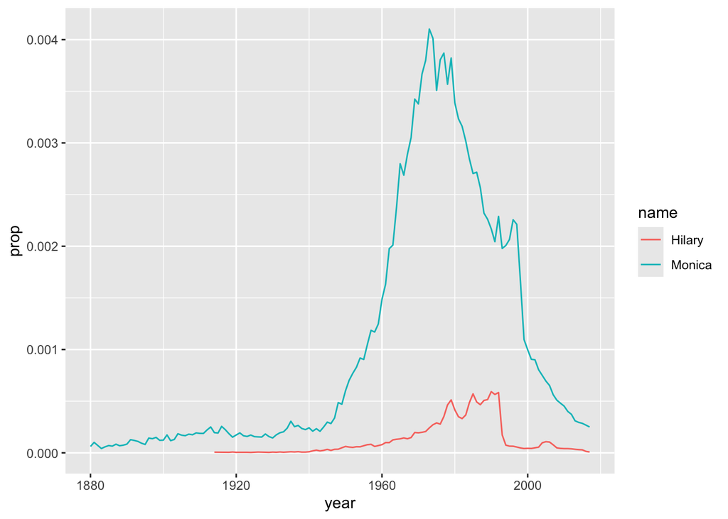

```r
monica_hilary <- babynames |> filter(sex == "F" & (name == "Monica" | name == "Hilary"))

ggplot(data = monica_hilary, aes(x = year, y = prop)) +
  geom_line(aes(colour = name))
```

# Your Turn 3

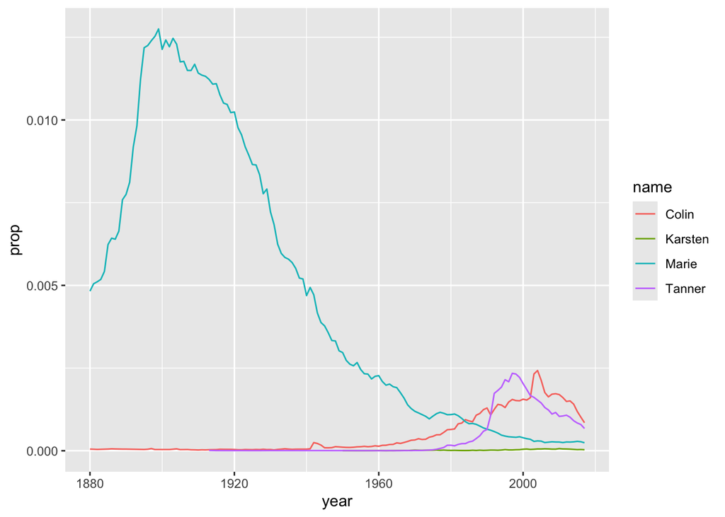

```r
five_cool_names <- babynames |> filter((name == "Tanner" & sex == "M") | (name == "Colin" & sex == "M") | (name == "Karsten" & sex == "M") | (name == "Marie" & sex == "F") | (name == "Alex" & sex == "M)"))

ggplot(data = five_cool_names, aes(x = year, y = prop)) +
  geom_line(aes(colour = name))
```

# Your Turn 4

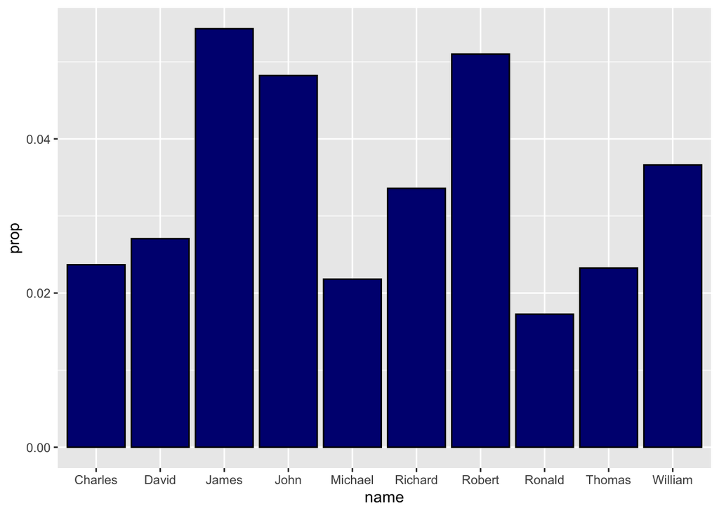

```r
male_names_1945 <- babynames |> filter(year == 1945 & sex == "M")
male_names_1945 <- male_names_1945 |> arrange(desc(n)) |> slice(1:10)

ggplot(data = male_names_1945, aes(x = name, y = prop)) +
  geom_col(colour = "black", fill = "navy")
```

## 3.3

```r
library(tidyverse)
slumajors_df <- read_csv("https://raw.githubusercontent.com/highamm/ds234_quarto/main/data_online/SLU_Majors_17_21.csv")
slumajors_df
```

```
# A tibble: 30 × 3
   Major                        nfemales nmales
   <chr>                           <dbl>  <dbl>
 1 Anthropology                       35     13
 2 Art & Art History                  62     11
 3 Biochemistry                       15      6
 4 Biology                           152     58
 5 Business in the Liberal Arts      192    301
 6 Chemistry                          28     20
 7 Conservation Biology               42     18
 8 Computer Science                   26     51
 9 Economics                         110    343
10 Economics-Mathematics              11     22
# ℹ 20 more rows
```

```r
slumajors_df |> mutate(ntotal = nfemales + nmales)
```

```
# A tibble: 30 × 4
   Major                        nfemales nmales ntotal
   <chr>                           <dbl>  <dbl>  <dbl>
 1 Anthropology                       35     13     48
 2 Art & Art History                  62     11     73
 3 Biochemistry                       15      6     21
 4 Biology                           152     58    210
 5 Business in the Liberal Arts      192    301    493
 6 Chemistry                          28     20     48
 7 Conservation Biology               42     18     60
 8 Computer Science                   26     51     77
 9 Economics                         110    343    453
10 Economics-Mathematics              11     22     33
# ℹ 20 more rows
```

```r
slumajors_df |> mutate(percfemale = 100 * nfemales / (nfemales + nmales))
```

```
# A tibble: 30 × 4
   Major                        nfemales nmales percfemale
   <chr>                           <dbl>  <dbl>      <dbl>
 1 Anthropology                       35     13       72.9
 2 Art & Art History                  62     11       84.9
 3 Biochemistry                       15      6       71.4
 4 Biology                           152     58       72.4
 5 Business in the Liberal Arts      192    301       38.9
 6 Chemistry                          28     20       58.3
 7 Conservation Biology               42     18       70
 8 Computer Science                   26     51       33.8
 9 Economics                         110    343       24.3
10 Economics-Mathematics              11     22       33.3
# ℹ 20 more rows
```

```r
slumajors_df <- slumajors_df |> mutate(ntotal = nfemales + nmales) |> mutate(percfemale = 100* nfemales / (nfemales + nmales))

slumajors_df |> mutate(morewomen = if_else(percfemale > 50,
                                           true = "Yes",
                                           false = "No"))
```

```
# A tibble: 30 × 6
   Major                        nfemales nmales ntotal percfemale morewomen
   <chr>                           <dbl>  <dbl>  <dbl>      <dbl> <chr>
 1 Anthropology                       35     13     48       72.9 Yes
 2 Art & Art History                  62     11     73       84.9 Yes
 3 Biochemistry                       15      6     21       71.4 Yes
 4 Biology                           152     58    210       72.4 Yes
 5 Business in the Liberal Arts      192    301    493       38.9 No
 6 Chemistry                          28     20     48       58.3 Yes
 7 Conservation Biology               42     18     60       70   Yes
 8 Computer Science                   26     51     77       33.8 No
 9 Economics                         110    343    453       24.3 No
10 Economics-Mathematics              11     22     33       33.3 No
# ℹ 20 more rows
```

```r
slumajors_df |> mutate(large_majority =
                          case_when(percfemale >= 70 ~ "female",
                                    percfemale <= 30 ~ "male",
                                    percfemale > 30 & percfemale < 70 ~ "none"))
```

```
# A tibble: 30 × 6
   Major                        nfemales nmales ntotal percfemale large_majority
   <chr>                           <dbl>  <dbl>  <dbl>      <dbl> <chr>
 1 Anthropology                       35     13     48       72.9 female
 2 Art & Art History                  62     11     73       84.9 female
 3 Biochemistry                       15      6     21       71.4 female
 4 Biology                           152     58    210       72.4 female
 5 Business in the Liberal Arts      192    301    493       38.9 none
 6 Chemistry                          28     20     48       58.3 none
 7 Conservation Biology               42     18     60       70   female
 8 Computer Science                   26     51     77       33.8 none
 9 Economics                         110    343    453       24.3 male
10 Economics-Mathematics              11     22     33       33.3 none
# ℹ 20 more rows
```

```r
slumajors_df <- slumajors_df |>
  mutate(morewomen = if_else(percfemale > 50,
                             true = "Yes",
                             false = "No")) |>
  mutate(large_majority =
           case_when(percfemale >= 70 ~ "female",
                     percfemale <= 30 ~ "male",
                     percfemale > 30 & percfemale < 70 ~ "none"))
```

# Exercises 1-3

```r
slumajors_df |> mutate(major_size = if_else(ntotal >= 100,
                                            true = "large",
                                            false = "small"))
```

```
# A tibble: 30 × 8
   Major   nfemales nmales ntotal percfemale morewomen large_majority major_size
   <chr>      <dbl>  <dbl>  <dbl>      <dbl> <chr>     <chr>          <chr>
 1 Anthro…       35     13     48       72.9 Yes       female         small
 2 Art & …       62     11     73       84.9 Yes       female         small
 3 Bioche…       15      6     21       71.4 Yes       female         small
 4 Biology      152     58    210       72.4 Yes       female         large
 5 Busine…      192    301    493       38.9 No        none           large
 6 Chemis…       28     20     48       58.3 Yes       none           small
 7 Conser…       42     18     60       70   Yes       female         small
 8 Comput…       26     51     77       33.8 No        none           small
 9 Econom…      110    343    453       24.3 No        male           large
10 Econom…       11     22     33       33.3 No        none           small
# ℹ 20 more rows
```

```r
slumajors_df |> mutate(major_size2 = case_when(ntotal >= 150 ~ "large",
                                               ntotal <= 149 & ntotal >= 41 ~ "medium",
                                               ntotal <= 40 ~ "small"))
```

```
# A tibble: 30 × 8
   Major  nfemales nmales ntotal percfemale morewomen large_majority major_size2
   <chr>     <dbl>  <dbl>  <dbl>      <dbl> <chr>     <chr>          <chr>
 1 Anthr…       35     13     48       72.9 Yes       female         medium
 2 Art &…       62     11     73       84.9 Yes       female         medium
 3 Bioch…       15      6     21       71.4 Yes       female         small
 4 Biolo…      152     58    210       72.4 Yes       female         large
 5 Busin…      192    301    493       38.9 No        none           large
 6 Chemi…       28     20     48       58.3 Yes       none           medium
 7 Conse…       42     18     60       70   Yes       female         medium
 8 Compu…       26     51     77       33.8 No        none           medium
 9 Econo…      110    343    453       24.3 No        male           large
10 Econo…       11     22     33       33.3 No        none           small
# ℹ 20 more rows
```

```r
slumajors_df |> mutate(ratio_f2m = nfemales / nmales)
```

```
# A tibble: 30 × 8
   Major    nfemales nmales ntotal percfemale morewomen large_majority ratio_f2m
   <chr>       <dbl>  <dbl>  <dbl>      <dbl> <chr>     <chr>              <dbl>
 1 Anthrop…       35     13     48       72.9 Yes       female             2.69
 2 Art & A…       62     11     73       84.9 Yes       female             5.64
 3 Biochem…       15      6     21       71.4 Yes       female             2.5
 4 Biology       152     58    210       72.4 Yes       female             2.62
 5 Busines…      192    301    493       38.9 No        none               0.638
 6 Chemist…       28     20     48       58.3 Yes       none               1.4
 7 Conserv…       42     18     60       70   Yes       female             2.33
 8 Compute…       26     51     77       33.8 No        none               0.510
 9 Economi…      110    343    453       24.3 No        male               0.321
10 Economi…       11     22     33       33.3 No        none               0.5
# ℹ 20 more rows
```

# 3.3.2

```r
slumajors_df |>
  summarise(meantotalmajor = mean(ntotal),
            totalgrad = sum(ntotal))
```

```
# A tibble: 1 × 2
  meantotalmajor totalgrad
           <dbl>     <dbl>
1           117.      3502
```

```r
slumajors_df |> summarise(totalobs = n())
```

```
# A tibble: 1 × 1
  totalobs
     <int>
1       30
```

# Exercise 4

```r
slumajors_df |> summarise(nfemales = sum(nfemales),
                          nmales = sum(nmales))
```

```
# A tibble: 1 × 2
  nfemales nmales
     <dbl>  <dbl>
1     1918   1584
```

# 3.3.3

```r
babynames |> group_by(year) |>
  summarise(totalbirths = sum(n))
```

```
# A tibble: 138 × 2
    year totalbirths
   <dbl>       <int>
 1  1880      201484
 2  1881      192696
 3  1882      221533
 4  1883      216946
 5  1884      243462
 6  1885      240854
 7  1886      255317
 8  1887      247394
 9  1888      299473
10  1889      288946
# ℹ 128 more rows
```

```r
babynames |> group_by(year) |>
  summarise(n_name = n())
```

```
# A tibble: 138 × 2
    year n_name
   <dbl>  <int>
 1  1880   2000
 2  1881   1935
 3  1882   2127
 4  1883   2084
 5  1884   2297
 6  1885   2294
 7  1886   2392
 8  1887   2373
 9  1888   2651
10  1889   2590
# ℹ 128 more rows
```

# Exercise 5-6

```r
babynames |> group_by(name) |> summarise(sum(n))
```

```
# A tibble: 97,310 × 2
   name      `sum(n)`
   <chr>        <int>
 1 Aaban          107
 2 Aabha           35
 3 Aabid           10
 4 Aabir            5
 5 Aabriella       32
 6 Aada             5
 7 Aadam          254
 8 Aadan          130
 9 Aadarsh        199
10 Aaden         4658
# ℹ 97,300 more rows
```

```r
babynames |> group_by(name) |> summarise(n())
```

```
# A tibble: 97,310 × 2
   name      `n()`
   <chr>     <int>
 1 Aaban        10
 2 Aabha         5
 3 Aabid         2
 4 Aabir         1
 5 Aabriella     5
 6 Aada          1
 7 Aadam        26
 8 Aadan        11
 9 Aadarsh      17
10 Aaden        18
# ℹ 97,300 more rows
```

# 3.3.4

```r
toy_df <- tibble(x = c(NA, 3, 4, 7),
                 y = c(1, 4, 3, 2),
                 z = c("A", "A", "B", NA))
toy_df
```

```
# A tibble: 4 × 3
      x     y z
  <dbl> <dbl> <chr>
1    NA     1 A
2     3     4 A
3     4     3 B
4     7     2 <NA>
```

```r
toy_df |> summarise(meanx = mean(x, na.rm = TRUE))
```

```
# A tibble: 1 × 1
  meanx
  <dbl>
1  4.67
```

```r
toy_df |> mutate(missingx = is.na(x))
```

```
# A tibble: 4 × 4
      x     y z     missingx
  <dbl> <dbl> <chr> <lgl>
1    NA     1 A     TRUE
2     3     4 A     FALSE
3     4     3 B     FALSE
4     7     2 <NA>  FALSE
```

```r
toy_df |> filter(is.na(x) != TRUE)
```

```
# A tibble: 3 × 3
      x     y z
  <dbl> <dbl> <chr>
1     3     4 A
2     4     3 B
3     7     2 <NA>
```

```r
toy_df |> filter(!is.na(x))
```

```
# A tibble: 3 × 3
      x     y z
  <dbl> <dbl> <chr>
1     3     4 A
2     4     3 B
3     7     2 <NA>
```

# Exercise 7

```r
toy_df |> filter(!is.na(z))
```

```
# A tibble: 3 × 3
      x     y z
  <dbl> <dbl> <chr>
1    NA     1 A
2     3     4 A
3     4     3 B
```

## 3.4 Practice

# Class Exercise 1

I think that 50% is the right cutoff because the variable is about whether there are more women or men in a major, and that is represented by 50%

# Class Exercise 4 - 5

```r
babynames |> group_by(year, sex) |>
  mutate(rank_var = rank(desc(n))) |>
  filter(rank_var == 1) |>
  ungroup() |>
  group_by(name) |>
  summarise(n_appear = n()) |>
  arrange(desc(n_appear))
```

```
# A tibble: 18 × 2
   name     n_appear
   <chr>       <int>
 1 Mary           76
 2 John           44
 3 Michael        44
 4 Robert         17
 5 Jennifer       15
 6 Jacob          14
 7 James          13
 8 Emily          12
 9 Jessica         9
10 Lisa            8
11 Linda           6
12 Emma            5
13 Noah            4
14 Sophia          3
15 Ashley          2
16 Isabella        2
17 David           1
18 Liam            1
```

# Class Exercise 6

Grouped by year and sex; slice is slicing the first 5 names for each sex each year.

```r
babynames_test <- babynames |>
  group_by(year, sex) |> mutate(ntest = n / prop)
babynames_test |> slice(1, 2, 3, 4, 5)
```

```
# A tibble: 1,380 × 6
# Groups:   year, sex [276]
    year sex   name          n   prop   ntest
   <dbl> <chr> <chr>     <int>  <dbl>   <dbl>
 1  1880 F     Mary       7065 0.0724  97605.
 2  1880 F     Anna       2604 0.0267  97605.
 3  1880 F     Emma       2003 0.0205  97605.
 4  1880 F     Elizabeth  1939 0.0199  97605.
 5  1880 F     Minnie     1746 0.0179  97605.
 6  1880 M     John       9655 0.0815 118400.
 7  1880 M     William    9532 0.0805 118400.
 8  1880 M     James      5927 0.0501 118400.
 9  1880 M     Charles    5348 0.0452 118400.
10  1880 M     George     5126 0.0433 118400.
# ℹ 1,370 more rows
```

```r
babynames_test |> ungroup() |> slice(1, 2, 3, 4, 5)
```

```
# A tibble: 5 × 6
   year sex   name          n   prop  ntest
  <dbl> <chr> <chr>     <int>  <dbl>  <dbl>
1  1880 F     Mary       7065 0.0724 97605.
2  1880 F     Anna       2604 0.0267 97605.
3  1880 F     Emma       2003 0.0205 97605.
4  1880 F     Elizabeth  1939 0.0199 97605.
5  1880 F     Minnie     1746 0.0179 97605.
```

## 3.4.2 Your Turn

# Your Turn 1

```r
toy_df |> group_by(z) |> mutate(rank_y = mean(y))
```

```
# A tibble: 4 × 4
# Groups:   z [3]
      x     y z     rank_y
  <dbl> <dbl> <chr>  <dbl>
1    NA     1 A        2.5
2     3     4 A        2.5
3     4     3 B        3
4     7     2 <NA>     2
```

```r
# calculating mean for each level of z

toy_df |> group_by(z) |> slice(1:3)
```

```
# A tibble: 4 × 3
# Groups:   z [3]
      x     y z
  <dbl> <dbl> <chr>
1    NA     1 A
2     3     4 A
3     4     3 B
4     7     2 <NA>
```

```r
#

toy_df |> group_by(z) |> filter(y >= 2)
```

```
# A tibble: 3 × 3
# Groups:   z [3]
      x     y z
  <dbl> <dbl> <chr>
1     3     4 A
2     4     3 B
3     7     2 <NA>
```

```r
# same as if we did not group_by() z
# grouping does matter if we use a summary function inside filter()

toy_df |> group_by(z) |> arrange(desc(y))
```

```
# A tibble: 4 × 3
# Groups:   z [3]
      x     y z
  <dbl> <dbl> <chr>
1     3     4 A
2     4     3 B
3     7     2 <NA>
4    NA     1 A
```

```r
# arrange() is not affected by group_by()

toy_df |> group_by(z) |> select(2)
```

```
# A tibble: 4 × 2
# Groups:   z [3]
  z         y
  <chr> <dbl>
1 A         1
2 A         4
3 B         3
4 <NA>      2
```

```r
# select() on a grouped data frame always returns the group variable.
```

# Your Turn 2

```r
toy_df |> mutate(x_over_y = x / y)
```

```
# A tibble: 4 × 4
      x     y z     x_over_y
  <dbl> <dbl> <chr>    <dbl>
1    NA     1 A        NA
2     3     4 A         0.75
3     4     3 B         1.33
4     7     2 <NA>      3.5
```

```r
# NA for any row with missing x or y

toy_df |> arrange(desc(x))
```

```
# A tibble: 4 × 3
      x     y z
  <dbl> <dbl> <chr>
1     7     2 <NA>
2     4     3 B
3     3     4 A
4    NA     1 A
```

```r
# arrange puts the missing value on the bottom. does not matter if arranged by ascending or descending order

toy_df |> filter(x < 5)
```

```
# A tibble: 2 × 3
      x     y z
  <dbl> <dbl> <chr>
1     3     4 A
2     4     3 B
```

```r
# gets rid of NA's no matter what

toy_df |> summarise(max(x))
```

```
# A tibble: 1 × 1
  `max(x)`
     <dbl>
1       NA
```

```r
# Returns a missing value if ANY value of x is NA

toy_df |> group_by(z) |> summarise(mean_x = mean(x))
```

```
# A tibble: 3 × 2
  z     mean_x
  <chr>  <dbl>
1 A         NA
2 B          4
3 <NA>       7
```

```r
# mean is missing for any level of the grouping variable z that has a missing x value
```

# Your Turn 3

1. mutate() -> This is generally safe because all it is doing is creating a new variable
2. arrange() -> This is generally safe because all of the data is still there just in a new order
3. filter() -> This is generally not safe because it will remove some data that does not fit the parameters that we are filtering by. You would have to be sure that you will never need access to the rows that you filter out again.
4. summarise() -> This is generally not safe because you’re changing the structure of the data to be only one row per group and you lose access to the original data
5. select() -> This is generally not safe because it will remove columns that you do not select. You would have to be sure that you will never need access to the rows that you filter out again.

# Your Turn 4

```r
slumajors_df |>
  summarise(meantotalmajor = mean(ntotal),
            totalgrad = sum(ntotal))
```

```
# A tibble: 1 × 2
  meantotalmajor totalgrad
           <dbl>     <dbl>
1           117.      3502
```

```r
slumajors_df |>
  mutate(meantotalmajor = mean(ntotal),
            totalgrad = sum(ntotal)) |>
  select(meantotalmajor, totalgrad, everything())
```

```
# A tibble: 30 × 9
   meantotalmajor totalgrad Major    nfemales nmales ntotal percfemale morewomen
            <dbl>     <dbl> <chr>       <dbl>  <dbl>  <dbl>      <dbl> <chr>
 1           117.      3502 Anthrop…       35     13     48       72.9 Yes
 2           117.      3502 Art & A…       62     11     73       84.9 Yes
 3           117.      3502 Biochem…       15      6     21       71.4 Yes
 4           117.      3502 Biology       152     58    210       72.4 Yes
 5           117.      3502 Busines…      192    301    493       38.9 No
 6           117.      3502 Chemist…       28     20     48       58.3 Yes
 7           117.      3502 Conserv…       42     18     60       70   Yes
 8           117.      3502 Compute…       26     51     77       33.8 No
 9           117.      3502 Economi…      110    343    453       24.3 No
10           117.      3502 Economi…       11     22     33       33.3 No
# ℹ 20 more rows
# ℹ 1 more variable: large_majority <chr>
```

```r
## mutate() just adds a new variable; keeps same number of rows and all other variables
## summarise() collapses data set so that there is 1 row per group
```

# Your Turn 5

```r
babynames_n_names <- babynames |> group_by(year) |>
  summarise(n_names = n())
## summarise is way more convenient here because it lets us get only 1 row per year
babynames_n_names
```

```
# A tibble: 138 × 2
    year n_names
   <dbl>   <int>
 1  1880    2000
 2  1881    1935
 3  1882    2127
 4  1883    2084
 5  1884    2297
 6  1885    2294
 7  1886    2392
 8  1887    2373
 9  1888    2651
10  1889    2590
# ℹ 128 more rows
```

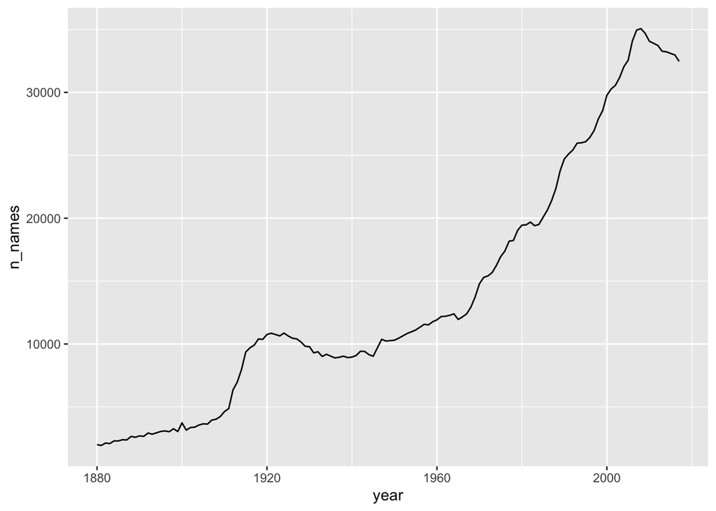

```r
ggplot(data = babynames_n_names, aes(x = year, y = n_names)) +
  geom_line()
```

# Your Turn 6

```r
babynames_n_s_names <- babynames |> group_by(year, sex) |>
  summarise(n_s_names = n())
babynames_n_s_names
```

```
# A tibble: 276 × 3
# Groups:   year [138]
    year sex   n_s_names
   <dbl> <chr>     <int>
 1  1880 F           942
 2  1880 M          1058
 3  1881 F           938
 4  1881 M           997
 5  1882 F          1028
 6  1882 M          1099
 7  1883 F          1054
 8  1883 M          1030
 9  1884 F          1172
10  1884 M          1125
# ℹ 266 more rows
```

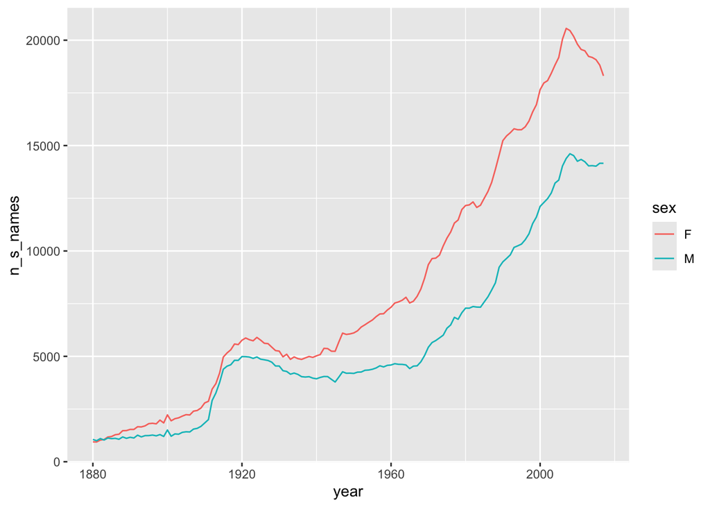

```r
ggplot(data = babynames_n_s_names, aes(x = year, y = n_s_names)) +
  geom_line(aes(colour = sex))
```

# Your Turn 7

```r
babynames_all_time_n_name <- babynames |> group_by(name) |>
  summarise(all_time_n_name = sum(n))
babynames_all_time_n_name |> arrange(desc(all_time_n_name))
```

```
# A tibble: 97,310 × 2
   name    all_time_n_name
   <chr>             <int>
 1 James           5173828
 2 John            5137142
 3 Robert          4834915
 4 Michael         4372536
 5 Mary            4138360
 6 William         4118553
 7 David           3624225
 8 Joseph          2614083
 9 Richard         2572613
10 Charles         2398453
# ℹ 97,300 more rows
```